# R Notebook for Pease Replication 2015 PID

Sam Davis, Ted Fetterling, Gereon Fredrickson, Abby Johnson

# Load libraries

```r
library("tidyverse")
library("haven")
library("olsrr")
library("descriptr")
library("modelr")
library("mosaic")
#install.packages("GGally")
library("GGally")
```

# Read in the original datafiles

```r
# to print this chunk, but not execute it again once the files are imported, add: eval=FALSE
# use the haven package to read in the data -- we need the MIDUS II data and the biomarker project data
midus2 <- read_spss("04652-0001-Data.sav")
bio <- read_spss("29282-0001-Data.sav")
saveRDS(midus2, "midus2.rds")
saveRDS(bio, "bio.rds")
```

# Read in the saved datafiles

```r
midus2 <- readRDS("midus2.rds")
bio <- readRDS("bio.rds")
```

# Subset the datafiles

```r
#Subset of both MIDUS2 and Bio datasets
midus2.subset <- midus2 %>%
  filter(SAMPLMAJ==1) %>%
  select(M2ID, B1PRSEX, B1PF7A, contains("B1SE6"), B1PAGE_M2, B1SE7I, B1SE7T, B1SE7BB, B1SE7EE, B1SNEURO, B1SEXTRA, B1SOPEN, B1SCONS2, B1SAGREE, B1SMPQAG) %>%
  filter(complete.cases(B1SNEURO, B1SEXTRA, B1SOPEN, B1SCONS2, B1SAGREE, B1SMPQAG, B1PRSEX, B1PAGE_M2, B1PF7A)) %>%
  mutate(IN_MIDUS2= 1)
bio.subset <- bio %>%
  select(M2ID, contains("B4Q4"), contains("B4Q5"), contains("B4Q6"), B4QTA_AG, B4QTA_AT, B4QTA_AR, B4QAE_AI, B4QAE_AO, B4QAE_AC) %>%
  filter(complete.cases(B4QTA_AG, B4QTA_AT, B4QTA_AR, B4QAE_AI, B4QAE_AO, B4QAE_AC)) %>%
  mutate(IN_BIO=1)
#Joined datasets
combine <- left_join(midus2.subset, bio.subset, by="M2ID") %>%
  select(M2ID, B1PF7A, B1SNEURO, B1SAGREE, B1SEXTRA, B1SOPEN, B1SCONS2, B4QTA_AG, B4QTA_AT, B4QTA_AR, B4QAE_AI, B4QAE_AO, B4QAE_AC, B1SMPQAG, B1PF7A, B1PAGE_M2, B1PRSEX, everything())
```

# create dataset for analysis

```r
# note which variables are categorical and numeric and tidy things up
analyze <- combine
all.vars <- names(analyze)
cat.vars <- c("M2ID", "B1PF7A")
analyze <- analyze %>%
  mutate_at(vars(all.vars), funs(as.numeric)) %>%
  mutate_at(vars(cat.vars), funs(as.factor)) %>%
  mutate(GENDER = factor(B1PRSEX, levels = c("1", "2"), labels = c("male", "female"))) %>%
  mutate(MALE = B1PRSEX - 1) %>%
  select(-B1PRSEX)
# create subset of just variable scale scores and the demographic variables
analyze <- analyze %>%
  select(B1SNEURO, B1SAGREE, B1SEXTRA, B1SOPEN, B1SCONS2,
         B4QTA_AG, B4QTA_AT, B4QTA_AR, B4QAE_AI, B4QAE_AO, B4QAE_AC,
         B1SMPQAG,
         B1PF7A,
         B1PAGE_M2,
         GENDER, MALE)
```

# Correlation matrix of agression variable and the Big 5 personality scales.

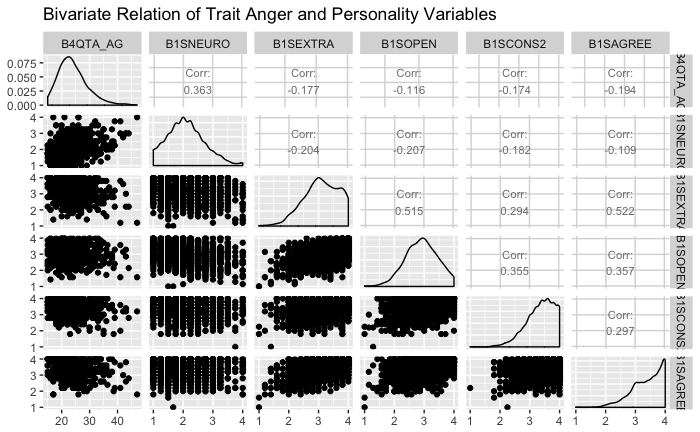

```r
scatterplot <- ggpairs(analyze, columns = c("B4QTA_AG", "B1SNEURO", "B1SEXTRA", "B1SOPEN", "B1SCONS2", "B1SAGREE"), upper = list(continuous = wrap("cor", size = 3)), title = "Bivariate Relation of Trait Anger and Personality Variables")
print(scatterplot, progress = FALSE)
```

# Next we will choose the Extraversion Big 5 personality variable and anger.

```r
ourvar <- analyze %>%
  select(B4QTA_AG, B1SEXTRA) %>%
  na.omit()
```

# Descriptive Stats for our variable

## Trait Anger

```r
summary_stats(ourvar$B4QTA_AG)
```

```
                         Univariate Analysis

 N                       627.00      Variance                 27.02
 Missing                   0.00      Std Deviation             5.20
 Mean                     24.01      Range                    32.00
 Median                   23.00      Interquartile Range       7.00
 Mode                     23.00      Uncorrected SS       378446.87
 Trimmed Mean             23.71      Corrected SS          16915.57
 Skewness                  0.96      Coeff Variation          21.65
 Kurtosis                  1.39      Std Error Mean            0.21

                               Quantiles

              Quantile                              Value

             Max                                    47.00
             99%                                    40.48
             95%                                    31.00
             90%                                    34.00
             Q3                                     27.00
             Median                                 23.00
             Q1                                     20.00
             10%                                    18.00
             5%                                     17.00
             1%                                     15.00
             Min                                    15.00

                             Extreme Values

                 Low                                High

  Obs                         Value       Obs                         Value
  77                           15         173                          47
  142                          15         495                          44
  206                          15         117                          43
  334                          15         216                          43
  367                          15         565                          42
```

## Extraversion

```r
summary_stats(ourvar$B1SEXTRA)
```

```
                        Univariate Analysis

 N                      627.00      Variance                 0.34
 Missing                  0.00      Std Deviation            0.58
 Mean                     3.13      Range                    2.80
 Median                   3.20      Interquartile Range      0.80
 Mode                     3.00      Uncorrected SS        6363.39
 Trimmed Mean             3.16      Corrected SS           213.28
 Skewness                -0.43      Coeff Variation         18.64
 Kurtosis                -0.26      Std Error Mean           0.02

                              Quantiles

              Quantile                            Value

             Max                                   4.00
             99%                                   4.00
             95%                                   3.80
             90%                                   4.00
             Q3                                    3.60
             Median                                3.20
             Q1                                    2.80
             10%                                   2.40
             5%                                    2.06
             1%                                    1.60
             Min                                   1.20

                            Extreme Values

                Low                                High

  Obs                        Value       Obs                        Value
  173                         1.2        13                           4
  381                         1.2        22                           4
  200                         1.4        30                           4
  452                         1.4        45                           4
  160                         1.6        51                           4
```

# Hypotheses

We are interested in assessing the relation between extraversion and trait anger. The extraversion variable is reflected by B1SEXTRA in the dataset and the trait anger variable is reflected by B4QTA_AG in the dataset. We are particularly interested in the significance test for the slope, not the intercept. Below is our statement of the null and alternative hypothesis for the slope.

Null: B1 (The slope) is equal to zero. Alternate: B1 is not equal to zero.

# Setting alpha and critical t.

```r
qt(c(.025, .975), df=625)
```

```
[1] -1.963767  1.963767
```

Our critical t is 1.96

# Centering extraversion at the mean and fitting the SLR model.

```r
ourvar <- ourvar %>%
  mutate(B1SEXTRA_m = B1SEXTRA - mean(B1SEXTRA))
our_model <- lm(B4QTA_AG ~ B1SEXTRA_m, data = ourvar)
ols_regress(our_model)
```

```
                        Model Summary
--------------------------------------------------------------
R                       0.177       RMSE                5.120
R-Squared               0.031       Coef. Var          21.322
Adj. R-Squared          0.030       MSE                26.215
Pred R-Squared          0.024       MAE                 3.953
--------------------------------------------------------------
 RMSE: Root Mean Square Error
 MSE: Mean Square Error
 MAE: Mean Absolute Error

                                ANOVA
----------------------------------------------------------------------
                 Sum of
                Squares         DF    Mean Square      F         Sig.
----------------------------------------------------------------------
Regression      531.333          1        531.333    20.268    0.0000
Residual      16384.238        625         26.215
Total         16915.570        626
----------------------------------------------------------------------

                                   Parameter Estimates
-----------------------------------------------------------------------------------------
      model      Beta    Std. Error    Std. Beta       t        Sig      lower     upper
-----------------------------------------------------------------------------------------
(Intercept)    24.013         0.204                 117.436    0.000    23.611    24.414
 B1SEXTRA_m    -1.578         0.351       -0.177     -4.502    0.000    -2.267    -0.890
-----------------------------------------------------------------------------------------
```

Our calculated t value in this model is found when dividing the estimate of the slope by the standard error. In this model, our t calc (or t star) is -1.578/.351=-4.502. This means that the estimate of the slope in this model is -4.502 standard errors away from the null hypothesis (0). We can conclude that is is highly unlikely that the null hypothesis is true for the slope (t=-4.502, p<.001). Therefore, we reject the null hypothesis.

Additionally, the 95% confidence interval (CI) for the distribution is -2.267 to -.890. This illustrates that of 95% of 95% of the CI’s that would be constructed across many random samples would contain the population slope. In this model, 0 is not included in the CI and therefore is unlikely to be a possible value for the slope.

According to the above results, extraversion is negatively associated with trait anger and the relation is statistically significant. Higher scores of extraversion are associated with lower scores of trait anger. Extraversion predicts 3.1% of the variance in trait anger (R-squared=.031). The standardized beta, equal to the correlation, between extraversion and trait anger is -.177 illustrating a weak, negative relation.

# Calculating predicted scores

Calculating the predicted y when x is 1 standard deviation below the mean, at the mean, and 1 standard deviation above the mean.

```r
predgrid <- data_grid(ourvar, B1SEXTRA_m = c(-.58, 0, .58))
predict(our_model, predgrid, interval = "confidence", level = .95)
```

```
       fit      lwr      upr
1 24.92806 24.36176 25.49435
2 24.01260 23.61106 24.41414
3 23.09714 22.53085 23.66343
```

```r
predict(our_model, predgrid, interval = "prediction", level = .95)
```

```
       fit      lwr      upr
1 24.92806 14.85757 34.99855
2 24.01260 13.95003 34.07517
3 23.09714 13.02665 33.16763
```

# Creating a scatterplot of our variable and agression with the fitted model.

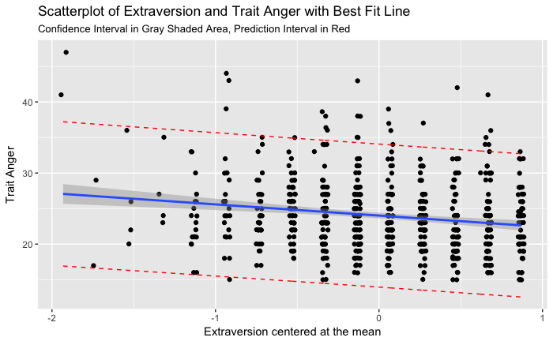

```r
temp_var <- predict(our_model, ourvar, interval="prediction")
ourvar_new <- cbind(temp_var, ourvar)
ggplot(ourvar_new, aes(x= B1SEXTRA_m, y= B4QTA_AG)) + geom_jitter() + geom_smooth(method = "lm", se= TRUE) + geom_line(aes(y=lwr), color="red", linetype="dashed") + geom_line(aes(y=upr), color="red", linetype="dashed") + labs(title="Scatterplot of Extraversion and Trait Anger with Best Fit Line", subtitle= "Confidence Interval in Gray Shaded Area, Prediction Interval in Red", x= "Extraversion centered at the mean", y= "Trait Anger")
```

# Graph of the residuals

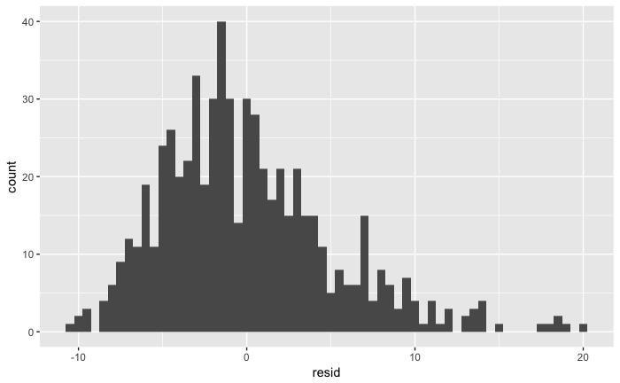

```r
ourvar<-ourvar %>%
  add_residuals(our_model)
ggplot(ourvar, aes(x= resid)) + geom_histogram(binwidth = .5)
```